# Hoja 4 (c): Tests Chi-cuadrado con R

## Ejercicio 4

Tests de independencia en tablas de contingencia.

```
##                       AUTOESTIMA
## TRABAJO                Baja Media Alta
##   Actividad remunerada   90    65   91
##   Ama de Casa           101    76   42
```

### Apartado a

Comprobación del p-valor y dibujar la distribución teórica, el cuantil y el valor observado.

H0 es la independencia de las muestras.

```r
resul=chisq.test(tabla)
resul
```

```
##
##  Pearson's Chi-squared test
##
## data:  tabla
## X-squared = 18.037, df = 2, p-value = 0.0001211
```

Rechazo H0, las muestras están relacionadas. Lo razonamos debido al p-valor.

```r
resul$expected
```

```
##                       AUTOESTIMA
## TRABAJO                     Baja    Media     Alta
##   Actividad remunerada 101.04516 74.59355 70.36129
##   Ama de Casa           89.95484 66.40645 62.63871
```

```r
resul$observed
```

```
##                       AUTOESTIMA
## TRABAJO                Baja Media Alta
##   Actividad remunerada   90    65   91
##   Ama de Casa           101    76   42
```

Calculamos el estadístico de manera manual.

- Forma 1:

```r
sum(resul$residuals^2)
```

```
## [1] 18.03737
```

- Forma 2:

```r
sum((resul$observed-resul$expected)^2/(resul$expected))
```

```
## [1] 18.03737
```

Para el cálculo del p-valor:

```r
nr=nrow(tabla)
nc=ncol(tabla)
gr_lib=(nr-1)*(nc-1)
1-pchisq(resul$statistic,df=gr_lib)
```

```
##    X-squared
## 0.0001211255
```

Podemos dibujar la fdd para la Chi-Cuadrado con esos grados de libertad.

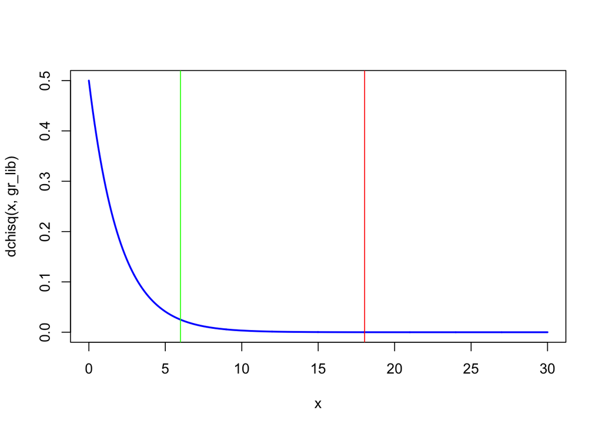

```r
curve(dchisq(x,gr_lib),0,30,1000,lwd=2,col="blue")
abline(v=resul$statistic,col="red")
abline(v=qchisq(0.95,gr_lib), col="green")
```

## Ejercicio 5

Tests de independencia en tablas de contingencia (Uso de la librería vcd).

```r
load("GSS.RData")
GSS
```

```
##       sex party count
## 1 mujeres   dem   279
## 2 hombres   dem   165
## 3 mujeres indep    73
## 4 hombres indep    47
## 5 mujeres   rep   225
## 6 hombres   rep   191
```

Podemos hacer una tabla de frecuencias con el paquete básico.

```r
tabla_GSS=xtabs(count ~ sex+party , data = GSS)
tabla_GSS
```

```
##          party
## sex       dem indep rep
##   mujeres 279    73 225
##   hombres 165    47 191
```

Realizamos el test Chi_Cuadrado.

```r
chisq.test(tabla_GSS)
```

```
##
##  Pearson's Chi-squared test
##
## data:  tabla_GSS
## X-squared = 7.0095, df = 2, p-value = 0.03005
```

Lo hacemos ahora con el paquete vcd. Instalo el paquete vcd

```r
library(vcd)
assocstats(tabla_GSS)
```

```
##                     X^2 df P(> X^2)
## Likelihood Ratio 7.0026  2 0.030158
## Pearson          7.0095  2 0.030054
##
## Phi-Coefficient   : NA
## Contingency Coeff.: 0.084
## Cramer's V        : 0.085
```

```r
#CrossTable(GSStab)
```

Me calcula todas las medidas de asociación. Me interesa el p-valor de pearson.

Hacemos un gráfico.

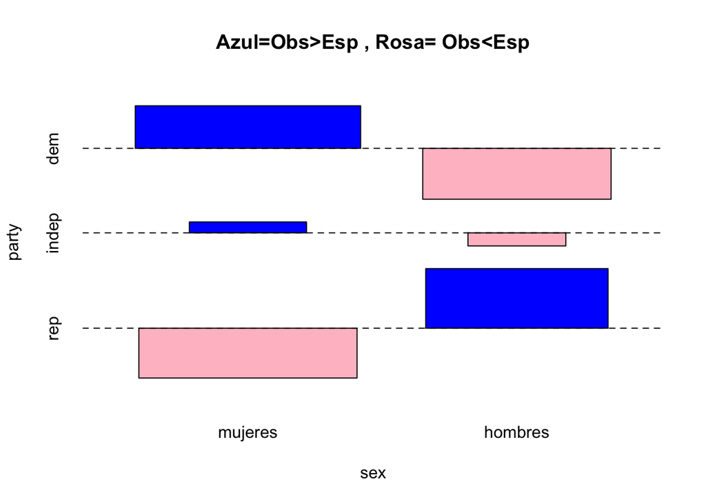

```r
assocplot(tabla_GSS, col=c("blue","pink"),
          main="Azul=Obs>Esp , Rosa= Obs<Esp")
```

Nos presenta la tabla de forma gráfica, mostrando como están distribuidas las categorías.

Parece que existe un comportamiento relacionado con el sexo.

## Ejercicio 6

Una dama británica sostenía que era capaz de adivinar si en un té con leche se ha vertido antes el té o la leche.

Para ello se realizó un experimento donde se le pidió que lo adivinara para 8 tazas:

```
H0:P[dice leche=/leche]=P[dice té/leche]
H1:P[dice leche=/leche]>P[dice té/leche]
```

```r
pruebate <-
  matrix(c(
    3,1,1,3), nrow = 2,
    dimnames = list(Predice = c("Leche", "Té"),
                    Verdad = c("Leche", "Té")))
pruebate
```

```
##        Verdad
## Predice Leche Té
##   Leche     3  1
##   Té        1  3
```

## Ejercicio 7

Gafas y antecedentes.

```r
gafasante <-
  matrix(c(1, 8, 5, 2), nrow = 2,
         dimnames = list(Gafas = c("Sí", "No"),
                         Antecedentes = c("Sí", "No")))
gafasante
```

```
##      Antecedentes
## Gafas Sí No
##    Sí  1  5
##    No  8  2
```

## Ejercicio 8

Test de McNemar (datos relacionados). Datos relacionados, por ejemplo antes-después.

Dos encuestas con un mes de separación, se pregunta a cada uno de los 1600 encuestados si aprueba o desaprueba a un gobernante.

```r
datos <- matrix(c(794, 86, 150, 570), nrow = 2,
       dimnames = list("Primera encuesta" = c("Aprueba", "Desaprueba"),
                       "segunda encuesta" = c("Aprueba", "Desaprueba")))
datos
```

```
##                 segunda encuesta
## Primera encuesta Aprueba Desaprueba
##       Aprueba        794        150
##       Desaprueba      86        570
```